# 🧮 Derivación, Visualización y Optimización de Funciones en Python

### Objetivo: Aplicar los conceptos fundamentales del cálculo diferencial en una variable a través de la derivación simbólica, la identificación de puntos críticos y la optimización de funciones.

### 👥 **Alumno**

- **🧑‍🎓 José Gómez Brizuela**

📅 *Entrega: Junio 2025*  
📘 *Módulo 3: Sesión N° 3*

## Librerías requeridas

```python
# Importación de librerías necesarias
import numpy as np
import sympy as sp
import matplotlib.pyplot as plt
from IPython.display import display, Math
from scipy.optimize import minimize
```

## 1.Definición y Derivación Simbólica de la Función:

- **Función a Analizar:** $f(x) = (x - 3)^2$

```python
# Función personalizada para mostrar expresiones simbólicas con formato LaTeX
def mostrar_latex(expr, nombre_funcion="f"):
    """
    Muestra en pantalla la representación LaTeX de una expresión simbólica.

    Parámetros:
    - expr: expresión simbólica de SymPy (por ejemplo, una función o derivada)
    - nombre_funcion: nombre que queremos que aparezca como etiqueta (por defecto, 'f')

    Resultado:
    - Muestra la función en formato matemático bonito usando LaTeX en un notebook de Colab
    """
    latex_expr = sp.latex(expr)
    display(Math(rf"{nombre_funcion}(x) = {latex_expr}"))


# Definimos la variable simbólica x, que representa nuestro eje horizontal
x = sp.Symbol('x')

# Definimos la función f(x) = (x - 3)^2
f = (x - 3)**2

# Mostramos la función original de manera elegante
mostrar_latex(f, "f")

# Calculamos la derivada de f con respecto a x
f_prime = sp.diff(f, x)

# Mostramos la derivada simbólicamente
mostrar_latex(f_prime, "f'")

# Buscamos los puntos donde la derivada se anula, es decir, los puntos críticos
solucion = sp.solve(f_prime, x)

# Mostramos el resultado en consola y también en formato matemático
print("Punto crítico donde f'(x) = 0:", solucion)
display(Math(rf"x = {solucion[0]}"))
```

$\displaystyle f(x) = \left(x - 3\right)^{2}$

$\displaystyle f'(x) = 2 x - 6$

```
Punto crítico donde f'(x) = 0: [3]
```

$\displaystyle x = 3$

## 2. Visualización de la Función y su Derivada:

$\displaystyle f(x) = \left(x - 3\right)^{2}$

$\displaystyle f'(x) = 2 x - 6$

$\displaystyle x = 3.0,\quad f(x) = 0.0$

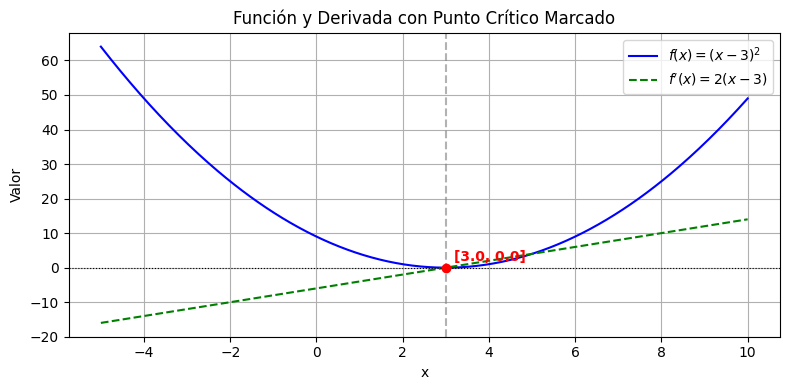

```python
# Mostramos nuevamente la función original y su derivada
mostrar_latex(f, "f")       # f(x) = (x - 3)^2
mostrar_latex(f_prime, "f'")  # f'(x) = 2(x - 3)

# === Determinación del Punto Crítico ===
# Resolvemos f'(x) = 0 para encontrar el mínimo o máximo
solucion = sp.solve(f_prime, x)

# Extraemos el punto crítico como número flotante (para graficar)
punto_critico = float(solucion[0])

# Evaluamos la función original en ese punto crítico para obtener el valor mínimo
valor_minimo = float(f.subs(x, punto_critico))

# Mostramos el punto crítico tanto en notación matemática como en consola
display(Math(rf"x = {punto_critico},\quad f(x) = {valor_minimo}"))
print("")

# === Preparación para graficar ===

# Convertimos las expresiones simbólicas a funciones numéricas para usar con NumPy
f_np = sp.lambdify(x, f, "numpy")         # Versión numérica de f(x)
f_prime_np = sp.lambdify(x, f_prime, "numpy")  # Versión numérica de f'(x)

# Generamos un rango de valores para analizar y graficar
x_vals = np.linspace(-5, 10, 400)         # Rango amplio que incluye el punto crítico
y_vals = f_np(x_vals)                     # Evaluamos f(x)
y_prime_vals = f_prime_np(x_vals)        # Evaluamos f'(x)

# === Gráfico Unificado: Función y Derivada ===

plt.figure(figsize=(8, 4))

# Graficamos la función original
plt.plot(x_vals, y_vals, label=r"$f(x) = (x - 3)^2$", color='blue')

# Graficamos la derivada como línea punteada
plt.plot(x_vals, y_prime_vals, label=r"$f'(x) = 2(x - 3)$", color='green', linestyle='--')

# Marcamos el punto crítico en rojo
plt.scatter([punto_critico], [valor_minimo], color='red', zorder=5)

# Líneas guía vertical y horizontal para resaltar el punto crítico
plt.axvline(punto_critico, color='gray', linestyle='--', alpha=0.6)
plt.axhline(0, color='black', linestyle=':', linewidth=0.8)

# Etiqueta visual del punto crítico
plt.text(punto_critico + 0.2, valor_minimo + 2.0,
         f"[{punto_critico:.1f}, {valor_minimo:.1f}]",
         color='red', fontsize=10, weight='bold')

# Configuraciones del gráfico
plt.title("Función y Derivada con Punto Crítico Marcado")
plt.xlabel("x")
plt.ylabel("Valor")
plt.legend()
plt.grid(True)
plt.tight_layout()
plt.show()
```

## 3. Optimización Numérica con SciPy:

```python
# === Función simbólica y derivada ===
x = sp.Symbol('x')  # Definimos x como variable simbólica

# Definimos la función f(x) = (x - 3)^2
f_expr = (x - 3)**2

# Creamos una versión numérica de la función para usar con NumPy
f = sp.lambdify(x, f_expr, "numpy")

# Derivamos simbólicamente para encontrar el punto crítico
f_prime = sp.diff(f_expr, x)

# Obtenemos el punto crítico (donde la derivada es cero)
punto_critico_simbolico = float(sp.solve(f_prime, x)[0])

# Evaluamos la función original en ese punto crítico
valor_minimo_simbolico = float(f_expr.subs(x, punto_critico_simbolico))

# === Definición de la función objetivo para optimización numérica ===
def funcion_objetivo(x):
    """
    Función que queremos minimizar numéricamente.

    Parámetros:
    - x: valor (o arreglo) sobre el que se evalúa la función

    Retorna:
    - Valor de (x - 3)^2, que tiene un mínimo en x = 3
    """
    return (x - 3)**2

# === Minimización numérica con SciPy ===
# Usamos un valor inicial arbitrario, como x = 0
resultado = minimize(funcion_objetivo, x0=0)

# Extraemos los resultados de la optimización
x_min_numerico = resultado.x[0]      # Valor de x donde se alcanza el mínimo
f_min_numerico = resultado.fun       # Valor mínimo de la función

# === Mostramos los resultados simbólicos y numéricos de forma elegante ===
display(Math(r"\text{Resultado simbólico:}"))
display(Math(rf"x = {punto_critico_simbolico},\quad f(x) = {valor_minimo_simbolico}"))

display(Math(r"\text{Resultado numérico con SciPy:}"))
display(Math(rf"x \approx {x_min_numerico:.6f},\quad f(x) \approx {f_min_numerico:.6f}"))

# También mostramos los resultados en consola para revisión rápida
print("")
print("Comparación de resultados")
print("Simbólico:", punto_critico_simbolico, "| Numérico:", x_min_numerico)
```

$\displaystyle \text{Resultado simbólico:}$

$\displaystyle x = 3.0,\quad f(x) = 0.0$

$\displaystyle \text{Resultado numérico con SciPy:}$

$\displaystyle x \approx 3.000000,\quad f(x) \approx 0.000000$

```
Comparación de resultados
Simbólico: 3.0 | Numérico: 2.9999999840660854
```

### ✅ Comparación y Verificación (Punto 3)

En esta sección se realiza la comparación del resultado simbólico y el numérico obtenidos para la función:

$$ f(x) = (x - 3)^2 $$

### 🔢 Resultados

- **Resultado simbólico** (derivación exacta):  
  $x = 3.0$, $f(x) = 0.0$
- **Resultado numérico** (SciPy `minimize`):  
  $x \approx 2.9999999840660854$, $f(x) \approx 0.000000$

### ✔️ Verificación

Ambos métodos coinciden con una diferencia menor a $1 \times 10^{-7}$, lo que confirma que:

- La solución numérica **converge con alta precisión** al resultado exacto.
- La función es **convexa** y el mínimo global se encuentra correctamente por ambos caminos.
- El método numérico es fiable incluso partiendo desde $x_0 = 0$, lejos del mínimo.

> *Este paso valida no solo el código, sino la confianza en los métodos de optimización que usamos día a día para entrenar modelos, lo que permite un grado de indeferencia en la elección del metodo a seguir.*

## 4. Documentación y Evidencias

# 🧠 Proyecto: Optimización Simbólica y Numérica en Python

## 📌 Resumen

Este proyecto tiene como objetivo ilustrar y comparar dos enfoques para encontrar el mínimo de una función cuadrática simple:

1. **Optimización simbólica**, usando derivadas exactas con `SymPy`.
2. **Optimización numérica**, usando el método `minimize` de `SciPy`.

Ambos métodos convergen al mismo punto mínimo, permitiendo visualizar el puente entre la matemática analítica y las herramientas prácticas utilizadas en ciencia de datos y machine learning.

## 📁 Estructura del proyecto

1. **Definición simbólica de la función**  
   Se utiliza `SymPy` para construir la función $ f(x) = (x - 3)^2 $ y calcular su derivada.
2. **Visualización con LaTeX**  
   Decidi crear una que permita mostrar la función y su derivada se simbólicamente para entender su comportamiento antes de resolverla, lo que enriquece la visualización matematica.
3. **Resolución simbólica del mínimo**  
   Se obtiene el punto crítico resolviendo $ f'(x) = 0 $, y se evalúa el valor mínimo exacto.
4. **Transformación numérica con `lambdify`**  
   Se convierte la función simbólica en una versión compatible con `NumPy` para graficar y comparar.
5. **Optimización numérica con `scipy.optimize.minimize`**  
   Se ejecuta un método de descenso para encontrar el mínimo desde un valor inicial arbitrario.
6. **Visualización gráfica**  
   Se presenta un gráfico conjunto de la función y su derivada, con el punto mínimo marcado.

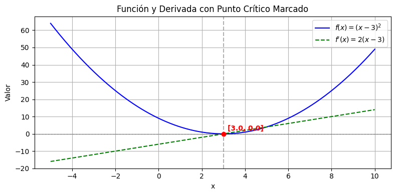

7. **Comparación final de resultados**  
   Se muestran los valores obtenidos por ambos métodos, validando su consistencia.

## ⚙️ Decisiones de diseño

- Se eligió una **función cuadrática simple** para centrarse en la comprensión del proceso, no en la complejidad del modelo.
- La implementación se dividió en pasos claros y separados, para facilitar el aprendizaje y permitir reutilización modular.
- Se incluyó una **visualización gráfica unificada**, que es clave en machine learning para interpretar el comportamiento de funciones de costo.
- El uso de `lambdify` permite un flujo natural entre **símbolos matemáticos** y **código computacional**.

## 🤖 Relevancia en Machine Learning

- En ML, la optimización es el **corazón del entrenamiento de modelos**: todo algoritmo aprende minimizando una función de costo.
- Este ejemplo simula de forma didáctica lo que hacen los algoritmos de descenso de gradiente en redes neuronales, regresión lineal y otros modelos.
- Aprender a conectar derivadas simbólicas con métodos numéricos permite comprender **por qué y cómo optimizamos modelos**.